# CSE4CG-PyOpenGL-Lab-04

## 5143135: Computer Graphics @ ZJU School of Software Technology

## Lab 4: Coordinate Systems, Projections, and Affine Transformations

Welcome to **5143135: Computer Graphics** !

After attending this lab class, you are expected to

- Understand different coordinate systems in an OpenGL application;
- Understand 2D orthogonal projection and 3D perspective projection; and
- Write Python programs with PyOpenGL to enable simple animations with affine transformations.

### Part 1: Coordinate Systems in OpenGL

In Lecture 4, we discussed the importance of different coordinate systems, enabling the representations of various objects in different settings. Actually, since the beginning of our labs, we have also practiced with several coordinate systems in OpenGL.

Recall that our goal in each task can be summarized as the creation of a window application displayed on the screen. The first coordinate system we handle is **screen (device) coordinate system**, in order to place the window application at a desired position. As indroduced in Lab 1, the screen coordinate system has its origin at the **upper-left** corner of the screen and uses *pixel (px)* as unit. The following statement in the program's main body refers to the creation of a window application with its upper-left corner 100 px distant from the left border and 100 px distant from the upper border.

```python
glutInitWindowPosition(u, v)                # Set the position (upper-left) of the window
```

In the *reshape* function defined by us, we encounter the second coordinate system, **viewport coordinate system**. The term **viewport** refers to the display area inside the window application (that is, the part of the window you would like use to display a scene; it can be the entire window or the partial window), and hence its coordinate system also uses *pixels (px)* as unit. However, the origin of the viewport coordinate system is at the **lower-left** corner of the area. The following statement in the *reshape* function means that the entire area of the window application is used as the viewport.

```python
glViewport(0, 0, w, h)                      # Set up the viewport (i.e., the display area inside the window)
```

The following figure illustrate the two different coordinate systems.

[figure not shown]

In the rest part of *reshape* function, we call an OpenGL function, like the one below, to specify the projection.

```python
glOrtho(0.0, w, 0.0, h, 0.0, 1.0)       # Set up a orthogonal projection (left, right, botton, top, nearVal, farVal)
```

It relates to the **clipping area**, that is, the area captured by a virtual *camera* in the **world space**, which implies what we can see on the window application is the result captured by the camera. The following two parts will discuss two projections and explain the corresponding clipping-area coordinate systems.

### Part 2: 2D Orthogonal Projection

In the previous labs, we displayed different 2D objects and used **orthogonal projection**, which is a form of parallel projection, where all the projection lines are *orthogonal* to the projection plane, resulting in every plane of the scene appearing in affine transformation on the viewing surface. In particular, we called the *glOrtho* function to achieve our goal. As orthogonal projection works for both 2D and 3D cases, we may instead use *gluOrtho2D* if tackling a 2D scene, as follows.

```python
gluOrtho2D(0.0, w, 0.0, h)          # Set up a 2D orthogonal projection (left, right, botton, top)
```

The projection's arguments also specify the range of the clipping-area in the **world coordiante system** (i.e., right handed cartesian coordinate system where we define the picture to be displayed). The above statement defines the clipping area covering the part of world space with the origin as its lower-left and (w, h) as its upper-right. World coordiante system is **continuous** and does not use a discrete unit like pixel. (That explains why the arguments are in float.)

**Note the vertices are created with coordinates in the world coordiante system.** For example, *glVertex2f(200.0, 200.0)* creates a vertex at (200.0, 200.0) in the world space. In Lab1-Task1, it was drawn at (200 px, 200 px) in the viewport coordinate system due to the overlapping.

In most cases, people prefer a normalized symmetrical pattern in the clipping area. Therefore, we update the arguments of the *gluOrtho2D* as follows.

```python
gluOrtho2D(-1.0, 1.0, -1.0, 1.0)    # Set up a 2D orthogonal projection (left, right, botton, top)
```

The following figure illustrates the difference between the two clipping areas.

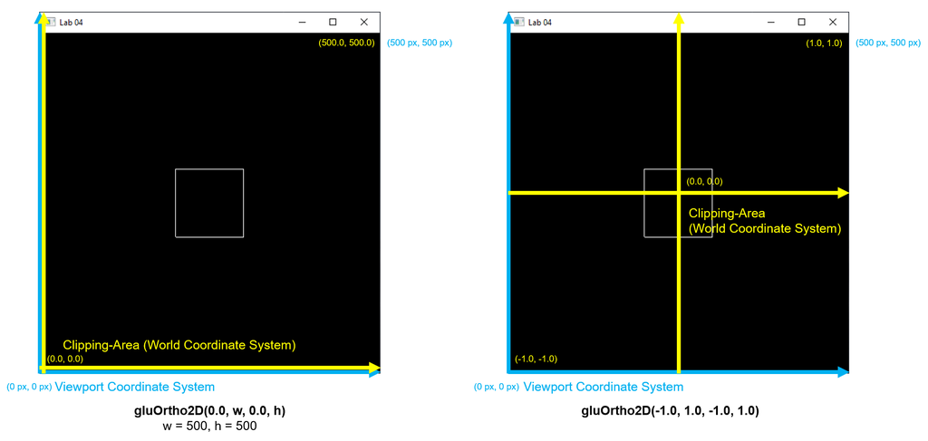

Now do you figure out that what the *window-viewport transformation* steps in the **Geometry** stage solves, mentioned in the pipeline in Lab 1? Yes, the objects in clipping area is mapped to the viewport in pixels, which can be later displayed to the screen. In this step, they will be distorted if the **aspect ratios** of the clipping area and viewport are different, as illustrated in the following figure.

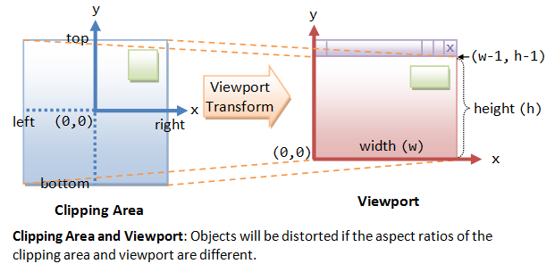

#### Practice: Modify the program in Lab1-Task1 to draw the same sqaure using the projection arguments described in this part.

- Think about what the coordinates of vertices should be in this case.

### Part 3: 3D Perspective Projection

Let's extend our focus to 3D cases. People would usually like to display the spatial structure of 3D objects, and thus use **perspective projection**. It is a linear projection where three dimensional objects are projected on a picture plane. This has the effect that **distant objects appear smaller than nearer objects**. The following figure illustrates the perspective projection.

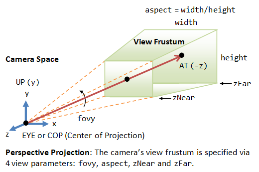

Perpective projection requires information on **camera** and **perpective parameters**. Different from 2D cases, it is crutial in perspective projection to determine the **position** (a.k.a. eye-point), **reference point** (a.k.a. at-point) and **up direction (normalized up vector)** of the camera in the **world space**. Note in the 3D world coordinate system, the z-axis describes the depth; its positive direction is towards our eyes. We can explicitly setup the camera by calling the *gluLookAt* function as follows.

```python
gluLookAt(0.0, 0.0, 1.0, 0.0, 0.0, -1.0, 0.0, 1.0, 0.0) # eyeX, eyeY, eyeZ, refX, refY, refZ, upX, upY, upZ
```

It places the camera at (0.0, 0.0, 1.0), makes it look at (0.0, 0.0, -1.0), and uses the positive direction of y-axis as the up direction, that is, (0.0, 1.0, 0.0). Note this function is called before creating any geometry.

We need then acquire four perspective parameters: **fovy**, **aspect**, **zNear**, **zFar**. *fovy* refers to the field of view angle (degrees) in the y direction; *aspect* refers to the aspect ratio (width / height); *zNear* refers to the distance (positive) from the viewer to the near cippling plain; and *zFar* refers to the distance (positive) from the viewer to the far cippling plain. we use the *gluPerspective* function to enable the projection with the parameter values, as follows.

```python
gluPerspective(45.0, w / h, 0.01, 10.0)
```

Similar to 2D orthogonal projection, perspective projection use the above information to clip a part of the world space captured by the camera, which is called **clipping volume**. The figure below illustrated an example clipping volume after perspective projection.

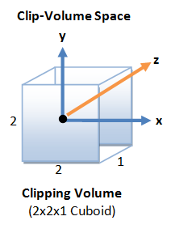

Here comes a siginificant difference: **the positive direction of the z-axis is away from us**! Recall the perspective example in Lecture 4, where the a further point (x, z) is mapped to (x/z, 1). In OpenGL, perspective projection flips the z-axis, and locates the near plane at z=0 and the far plane at z=1 in the clipping volume space. The x-axis and y-axis are similar to the symmetrical normalized pattern in the clipping area.

Now, let's use the following Python program to create the skeleton of a cube with PyOpenGL.

```python
from OpenGL.GL import *
from OpenGL.GLUT import *
from OpenGL.GLU import *

import math
import numpy as np

def display():
    vertices = np.array([       [-0.1, -0.1, -0.0],     # P0
                                [0.1, -0.1, -0.0],      # P1
                                [0.1, 0.1, -0.0],       # P2
                                [-0.1, 0.1, -0.0],      # P3
                                [-0.1, -0.1, -0.2],     # P4
                                [0.1, -0.1, -0.2],      # P5
                                [0.1, 0.1, -0.2],       # P6
                                [-0.1, 0.1, -0.2],      # P7
                                ])

    faces = np.array([          [0, 1, 2, 3],       # Front
                                [4, 5, 6, 7],       # Back
                                [3, 2, 6, 7],       # Top
                                [0, 1, 5, 4],       # Bottom,
                                [4, 0, 3, 7],       # Left,
                                [1, 5, 6, 2]        # Right
                                ])

    # Reset
    glClear(GL_COLOR_BUFFER_BIT | GL_DEPTH_BUFFER_BIT)
    glLoadIdentity()

    # Reset the camera
    gluLookAt(0.0, 0.0, 1.0, 0.0, 0.0, -1.0, 0.0, 1.0, 0.0)

    # Move the origin
    glTranslatef(0.0, 0.0, -0.5)

    # Draw the cube using lines
    glBegin(GL_LINES)
    for i in range(6):
        face = faces[i]

        glVertex3fv(vertices[face[0]])
        glVertex3fv(vertices[face[1]])
        glVertex3fv(vertices[face[1]])
        glVertex3fv(vertices[face[2]])
        glVertex3fv(vertices[face[2]])
        glVertex3fv(vertices[face[3]])
        glVertex3fv(vertices[face[3]])
        glVertex3fv(vertices[face[0]])
    glEnd()

    glutSwapBuffers()


def idle():
    display()


def initRendering():
    glEnable(GL_DEPTH_TEST)
    # glEnable(GL_LIGHTING)
    # glEnable(GL_LIGHT0)


def reshape(w, h):
    glViewport(0, 0, w, h)

    glMatrixMode(GL_PROJECTION)
    glLoadIdentity()
    gluPerspective(45.0, w / h, 0.01, 100.0)
    glMatrixMode(GL_MODELVIEW)
    glLoadIdentity()


w, h = 500, 500
u, v = 100, 100

glutInit()
glutInitDisplayMode(GLUT_RGB |
                    GLUT_DOUBLE |
                    GLUT_DEPTH)

glutInitWindowSize(w, h)
glutInitWindowPosition(u, v)
glutCreateWindow("Lab 04")

initRendering()

glutReshapeFunc(reshape, w, h)
glutDisplayFunc(display)
glutIdleFunc(idle)
glutMainLoop()
```

#### Practice: Try the following actions and understand the functions better.

- Change the values of arguments in *gluLookAt* and explain any difference in the results produced.
- Change the values of arguments in *gluPerspective* and explain any difference in the results produced.

### Part 4: Affine Transformations

OpenGL enables various affine transformations (i.e., linear transformations and translation), which we discussed in Lecture 4, by functions. In the previous part, we have already used the *glTranslatef* to move the origin of the coordinate system. In fact, affine transformations can help us to achieve something more than static scenes, that is, **animations**.

In Lab 1, we mentioned that registering a function to *glutIdleFunc* may enable animations. Since the function *idle* registered only includes the function *display*, let's try to modify it for animations.

Suppose we would like the square created in Part 2's practice to **rotate** around the z-axis. OpenGL provides the function *glRotate* for rotating the origin of the current space. The statement enables the **anti-clockwise rotation** of the origin around the z-axis by 0.1 degree.

```python
glRotate(0.1, 0.0, 0.0, 1.0)
```

Now, let's think about how we can create an animation using the function. We know that an animation is a sequence of static scenes or images. As OpenGL refreshes the window application at a certain frequency, it is possible to animate the square by rotating it a bit after each refresh.

For the function registered to *glutDisplayFunc* cannot take any arguments, we declare a global variable *deg* in the main body, representing the amount of rotation (in degrees) and initialize it as *0*. In the *display* function, we need to use keyword *global* to assert *deg* as a global variable, and then call *glRotate* with *deg* as the first argument's value, followed by incrementing it by *1.0* (or any incremental you prefer; larger, quicker the rotation), as follows.

```python
global deg
glRotate(deg, 0.0, 0.0, 1.0)
deg += 1.0
```

Now, please organize the program as follows and run it to see what happpens.

```python
from OpenGL.GL import *
from OpenGL.GLUT import *
from OpenGL.GLU import *


def display():
    glClear(GL_COLOR_BUFFER_BIT | GL_DEPTH_BUFFER_BIT)
    glLoadIdentity()

    global deg
    glRotate(deg, 0.0, 0.0, 1.0)
    deg += 1.0

    glBegin(GL_LINE_LOOP)
    glColor3f(1.0, 1.0, 1.0)
    glVertex2f(-0.1, -0.1)
    glVertex2f(0.1, -0.1)
    glVertex2f(0.1, 0.1)
    glVertex2f(-0.1, 0.1)
    glEnd()

    glutSwapBuffers()


def idle():
    display()


def initRendering():
    glEnable(GL_DEPTH_TEST)
    # glEnable(GL_LIGHTING)
    # glEnable(GL_LIGHT0)


def reshape(w, h):
    glViewport(0, 0, w, h)

    glMatrixMode(GL_PROJECTION)
    glLoadIdentity()
    gluOrtho2D(-1.0, 1.0, -1.0, 1.0)

    glMatrixMode(GL_MODELVIEW)
    glLoadIdentity()


w, h    = 500, 500
u, v    = 100, 100
deg     = 0

glutInit()
glutInitDisplayMode(GLUT_RGB |
                    GLUT_DOUBLE |
                    GLUT_DEPTH)

glutInitWindowSize(w, h)
glutInitWindowPosition(u, v)
glutCreateWindow("Lab 04")

initRendering()

glutReshapeFunc(reshape, w, h)
glutDisplayFunc(display)
glutIdleFunc(idle)
glutMainLoop()
```

### Questions

#### Q1: Write a Python program with PyOpenGL to modify the program in Part 3, in order to animate the cube by rotating it around the y-axis for 0.5 degree after each screen refreshing.

#### Q2: Write a Python program with PyOpenGL to modify the program in Part 4, in order to animate the square by translating it along the x-axis towards the positive direction for 0.0001 after each screen refreshing.

#### A sample solution is to be provided after the lab on the DingTalk group :)